# BI1363: Föreläsning 6 Test av proportioner Oktober 2020 Adam Flöhr, BT, SLU

# Innehåll

Tester för proportioner

- Test och konfidensintervall för ett stickprov
- Binomialtest
- Test och konfidensintervall med två stickprov

# Introduktion

## Binära data

$n$ observationer av ett binärt resultat

Den skattade proportionen ges av $\hat p = \frac{\text{Antal positiva utfall}}{n}$

**Fördelning för antal positiva utfall**

$n$ oberoende observationer av en binär variabel

Antalet positiva utfall följer en binomialfördelning med någon sannolikhet $p$ och en storlek $n$

I en binomialfördelning gäller $E(X) = np$ och $Var(X) = np(1-p)$

Naturligt att uppskatta $p$ med $\hat p$, den observerade proportionen

## Normalapproximation

Två alternativ för hypotestester och konfidensintervall:

- exakt beräkning baserad på binomialfördelningen
- normalapproximation

## Normalapproximation av en binomialfördelning

Om andelen $p$ är nära $0.5$ och $n$ är stort, kan binomialen approximeras med en normalfördelning

Tumregel: $np > 10$ och $n(1-p)>10$

## Exempel. Binomial och normal

Insamlade $ 60 $ växter och kontrollera mögel skador

Om man antar självständighet följer antalet anläggningar med skador en binomial distribution

Låt oss anta $ 30 $ procent av växter (i befolkningen) är skadade

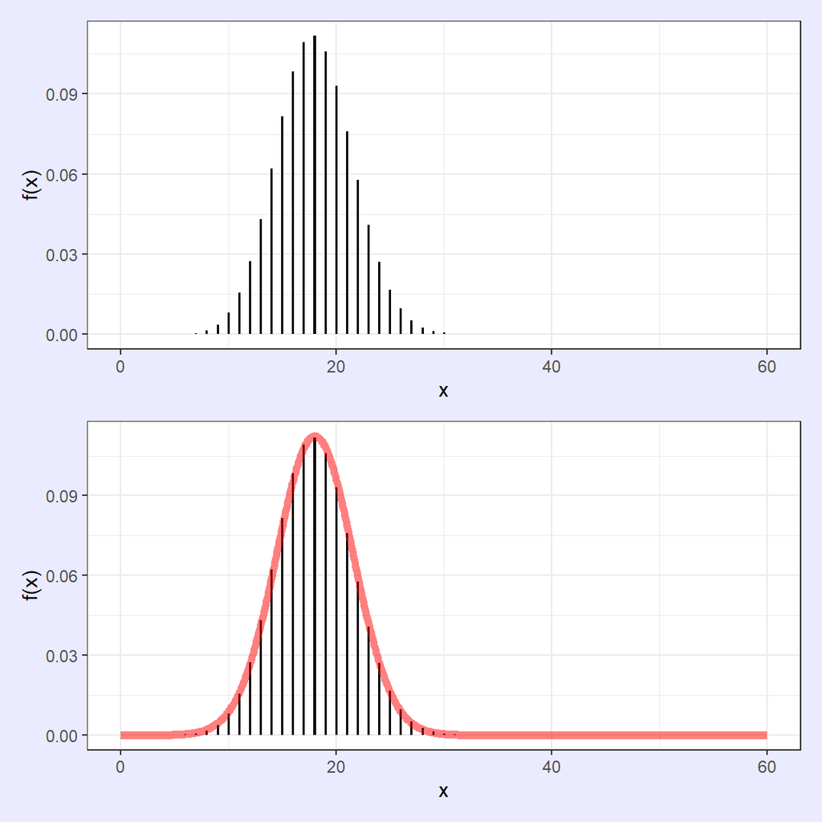

Antalet skadade växter är $Bin(60, 0,3)$

Förväntat värde är $60 \cdot 0.3 = 18$, variansen är $60 \cdot 0.3 \cdot 0.7 = 12.6$

En normal approximation $N(18, 12,6)$

# Hypotestester för proportioner, ett prov

## z-test för proportioner

En hypotes test jämföra den observerade andelen $p $ till några null hypotesen $p_0$

Förlitar sig på den normala approximationen av binomial

**Standardinställningen för HT**

- Null-hypotes och alternativ hypotes
- Punktuppskattningar från data
- Testfunktion inklusive punktuppskattningar, nollhypotesen och ett visst mått på slumpmässighet
- Fördelningen av värdet på testfunktionen *under null*
- En p-värdeberäkning från fördelningen

## z-test for proportions

**Hypoteser**

$$H_{0}: p = p_0 \qquad H_{1}: p \neq p_0$$

Kan också ha ensidig alternativ hypotes

**Point estimate**

The estimated proportion $\hat p$

**Test function**

The test function is given by

$$z_{obs} = \frac{\hat p - p_0}{\sqrt{\frac{p_0(1-p_0)}{n}}}$$

Note similarity to the test function in the t-test

**Distribution**

Assumptions: independent observations, valid normal approximation

Under the assumptions and the null, $z_{obs}$ follows a normal distribution with mean zero and variance one

The p-value is calculated as the probability of the observed value or something more extreme (the tail probability)

For a two-sided test, the p-value is multiplied by two

## z-test for a proportion

The one-sample z-test tests if a proportion is equal to some specific null value

| Null hyp. | $H_{0}: p = p_0$ |
| --- | --- |
| Alt. hyp. | $H_{1}: p \neq p_0$ |
| Point est. | $\hat p$, observed proportion |
| Test function | $z_{obs} = \frac{\hat p - p_0}{\sqrt{\frac{p_0(1-p_0)}{n}}}$ |
| Distribution | Standard normal distribution |
| Assumptions | independent observations and valid normal approximation |

## z-test. Example

We continue our previous example on moldy plants

$n = 60$ and say we want to test against $p_0 = 0.3$

In our sample we find $15$ damaged plants, so $\hat p = \frac{15}{60} = 0.25$

**Hypotheses**

$$H_0: p = 0.3 \qquad H_1: p \neq 0.3$$

**Poänguppskattning** Den uppskattade andelen $\hat p$

Under antagandena och null följer $z_{obs}$ en normalfördelning med medelvärde noll och varians ett

P-värdet beräknas som sannolikheten för det observerade värdet eller något mer extremt (svanssannolikheten)

Z-testtestet med ett prov om en andel är lika med ett visst null-värde

[output not shown]

# Z-test. Exempel

Vi fortsätter vårt tidigare exempel på mögliga växter

$n = 60 $ och säger att vi vill testa mot $p_0 = 0,3 $

I vårt urval hittar vi $ 15 $ skadade växter, så $\hat p = \frac{15}{60} = 0.25$

**Hypoteser** **Testfunktion**

$$z_{obs} = \frac{0.25 - 0.3}{\sqrt{\frac{0.3 \cdot 0.7}{60}}} = -0.8452$$

## Illustration av p-värdet

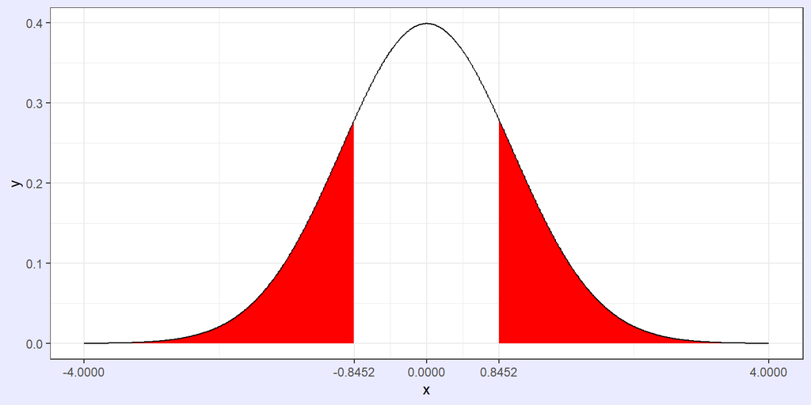

The test function value $z = -0.8452$ is on the standardized scale

The tail probability can be calculated by looking up the standardized value in a normal distribution table or the computer

```r
2 * pnorm(-0.8452)
```

```
## [1] 0.3979992
```

## Z-testet och den normala approximationen

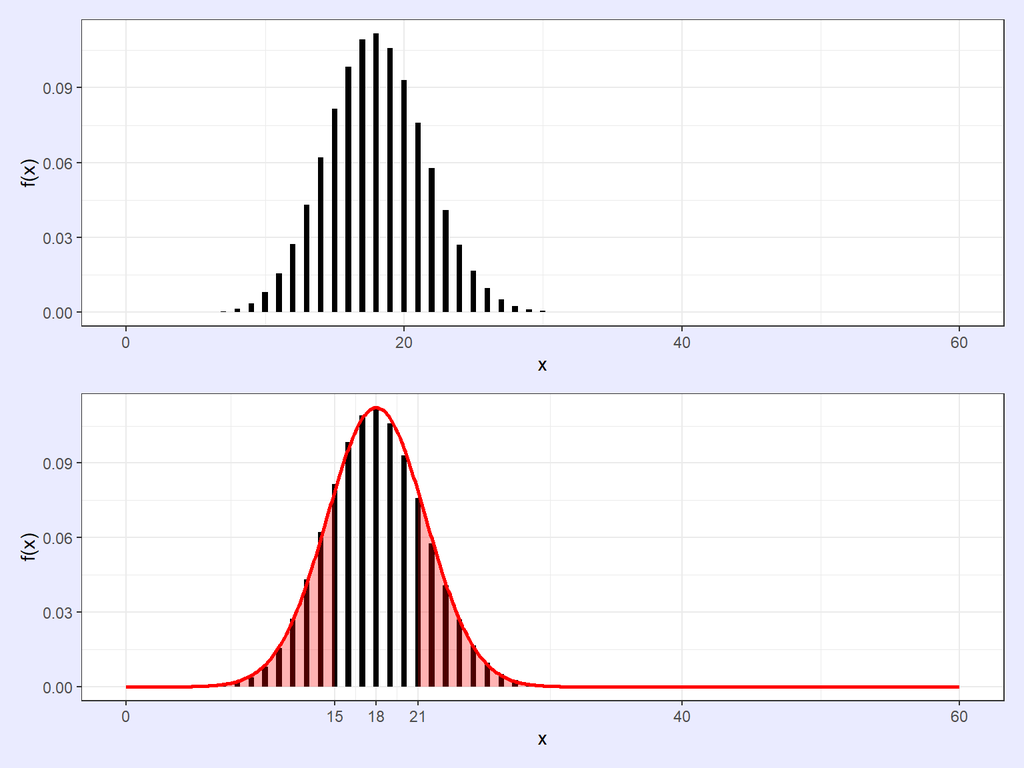

Enligt nollhypotesen följer antalet skadade växter en binomialfördelning $Bin(60, 0,3)$

P-värdet från z-testet kan ses som en sannolikhetsberäkning vid normal approximation av det binomial

```r
n <- 60
p <- 0.3
2 * pnorm(15, n * p, sqrt(n * p * (1 - p)))
```

```
## [1] 0.3980247
```

## Binomialtestet

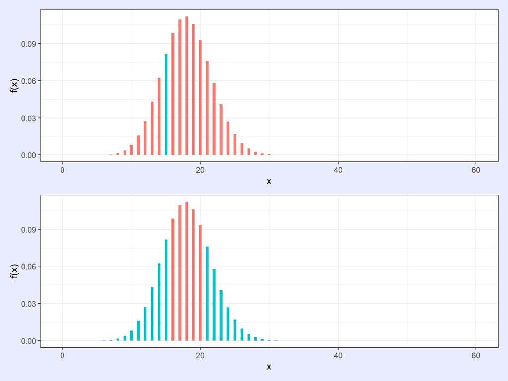

Detta tyder på att vi kan beräkna ett p-värde direkt från binomial distribution

Antalet växter är $Bin(60, 0,3)$

Vi observerar 15 skadade växter

Det ensidiga p-värdet är sannolikheten för att få 15 eller mindre skadade växter

```r
pbinom(15, 60, 0.3) # 0.2438
```

Det dubbelsidiga p-värdet är den summerade sannolikheten för utfall som är mindre sannolika än det observerade resultatet

Detta innebär att staplar som är lägre än baren vid 15

```r
sum(dbinom(c(0:15, 21:60), 60, 0.3)) # 0.4816
```

## Konfidensintervall för proportioner, ett prov

Konstruera konfidensintervallet baserat på tabellvärden från den standardiserade normala fördelningen

I z-testet baseras standardfelet på nollhypotesen $p_0$

I CI standardfelet är baserat på den observerade $\hat p$

**Formel**

$$\hat p \pm z_{1-\alpha/2} \sqrt{\frac{\hat p (1 - \hat p)}{n}}$$

Fortsätter exemplet,

$$0.25 \pm 1.96 \sqrt{\frac{0.25 \cdot 0.75}{60}}$$

Detta ger intervallet $(0.140, 0.360$)

# Hypotestester för proportioner, tvåprover

## Proportiontest med två prov

Liknande generalisering som t-testet med två prov

Vi har två prover av binära data och kan uppskatta tre proportioner

$\hat p_1$ and $\hat p_2$ are the proportions in each sample

$\hat p_0$ is the proportion in the merged sample

**Hypoteser**

$H_0: p_1 = p_2$

$H_1: p_1 \neq p_2$

Ensidig alternativ hypotes också möjlig

**Testfunktion**

$$z_{obs} = \frac{\hat p_1 - \hat p_2}{\sqrt{\hat p_0 (1 - \hat p_0)\left( \frac{1}{n_1} + \frac{1}{n_2} \right)}}$$

**Distribution**

$z_{obs}$ är ungefär standard normal distribueras för * stora prov *

Tumregel: $n_1 \hatt p_0, n_2 \hat p_0, n_1(1-\hat p_0)$ och $n_2(1-\hat p_0)$ bör alla vara större än $10$

## Två-exempel, exempel

Träd i södra och norra Sverige kontrolleras för en viss sjukdom

$ 50 $ av $ 100 $ är sjuka i söder och $ 52 $ av $ 200 $ är sjuka i norr

$$\hat p_1 = \frac{50}{100} = 0.50 \qquad \hat p_2 = \frac{52}{200} = 0.26$$

Den sammanslagna andelen är $\hat p_0 = \frac{50+52}{100+200} = 0.34$

**Test för lika stora andelar sjuka träd**

$$H_0: p_1 = p_2 \qquad H_1: p_1 \neq p_2$$

**Testfunktion**

$$z_{obs} = \frac{0.50 - 0.26}{\sqrt{0.34 (1 - 0.34)\left( \frac{1}{100} + \frac{1}{200} \right)}} = 4.137$$

Vi kan få motsvarande (dubbelsidiga) p-värde från datorn: $p = 0,000035$

## Två-prov, Konfidensintervall

Konfidensintervallet för skillnaden i proportioner ges av

$$\hat p_1 - \hat p_2 \pm z_{1-\alpha/2} \sqrt{\hat p_0 (1 - \hat p_0)\left( \frac{1}{n_1} + \frac{1}{n_2} \right)}$$

$$0.5-0.26 \pm 1.96 \sqrt{0.34 \cdot 0.66 (0.01 + 0.005)} = 0.24 \pm 0.11$$

or $[0.13,0.35]$